# R Notebook

# Introduction

- Why R and not Excel?
  - I have reluctantly realized that R might not always be better BUT
  - R is very flexible
  - R works with large data
  - R allows rapidly reproduce complex visualizations for many different datasets
    - Develop it once
  - There are a package system making many otherwise complex operations available

# Looking for help

- Use the ‘?’ function!
- Use Google
- Particularly look for StackOverflow threads - this is a forum which curates good answers to programming questions

# Basic R vs. Tidyverse

- Tidyverse: A collection of packages headed by ‘Hadley’
- Aims at making processing in R easy-to-use
- ‘Why are you telling me this? I like base R’
  - Preferenses are up to each and everyone
  - It makes some types of operations nicer for many people
  - You will never escape base R
  - Here, I will in some, but not all, cases show both ways (`gather`)

## Running NormalyzerDE

Run from `quantitativeproteomics.org/NormalyzerDE`

Without batch correction:

- Log2 transformed
- Comparing groups 9-8 from design

With batch correction:

- Advanced setting `Batch column` set to `time`

I retrieved the batch values and inserted them in the first matrix.

# The wide- and the long- formats

- We are used to looking at expression data in wide format
  - One feature per row

# Load required packages

`Tidyverse` contains several packages which will be used here.

- `ggplot2` - Perhaps is most famous package, very popular for visualizations
- `readr` - Provides functions for reading and writing data
- `dplyr` - Provides functions for working with datasets

```r
library(tidyverse)
# Could also be loaded separately:
# library(ggplot2)
# library(dplyr)
# library(readr)
```

# Loading data

- Data obtained from NormalyzerDE
- The design matrix
  - Contains your sample setup - information linked to each of your samples
  - Both biological and technical variables could be tracked here

Note that the spaces in the column headers by default automatically are replaced with dots (`.`).

```r
data_fp <- "spikein_data/SpikeinWorkshop_nobatch_stats.tsv"
design_fp <- "spikein_data/input_design.tsv"
# Tidyverse (readr package)
full_data_df <- read_tsv(data_fp)
design_df <- read_tsv(design_fp)
design_df
```

| sample | group | time |
| --- | --- | --- |
| dil9_5 | 9 | late |
| dil9_4 | 9 | late |
| dil8_1 | 8 | late |
| dil8_2 | 8 | late |
| dil8_3 | 8 | late |
| dil9_3 | 9 | late |
| dil8_5 | 8 | late |
| dil8_4 | 8 | late |
| dil9_2 | 9 | late |
| dil9_1 | 9 | late |

[output cut: 8 more lines]

```r
# Base R
full_data_df <- read.table(data_fp, sep="\t", header = TRUE)
design_df <- read.table(design_fp, sep="\t", header = TRUE)
# IMPORTANT! Otherwise the samples will be seen as numeric, and will give you wrong columns when taking them from the data
# full_data_df[, design_df$sample] will not behave as you expect
design_df$sample <- as.character(design_df$sample)
design_df$time <- as.character(design_df$time)
design_df$group <- as.factor(design_df$group)
```

## Investigate the data

- `str`: Produces a brief summary of the object that is given to it
- `head`: Retrieve the first `n` rows from a data.frame or matrix, where `n` here is specified to 10
- `colnames`: Show the column names of the data frame (or matrix)

```r
str(design_df)
```

```
'data.frame':   18 obs. of  3 variables:
 $ sample: chr  "dil9_5" "dil9_4" "dil8_1" "dil8_2" ...
 $ group : Factor w/ 2 levels "8","9": 2 2 1 1 1 2 1 1 2 2 ...
 $ time  : chr  "late" "late" "late" "late" ...
```

```r
head(design_df, 10)
```

|  | sample | group | time |
| --- | --- | --- | --- |
| 1 | dil9_5 | 9 | late |
| 2 | dil9_4 | 9 | late |
| 3 | dil8_1 | 8 | late |
| 4 | dil8_2 | 8 | late |
| 5 | dil8_3 | 8 | late |
| 6 | dil9_3 | 9 | late |
| 7 | dil8_5 | 8 | late |
| 8 | dil8_4 | 8 | late |
| 9 | dil9_2 | 9 | late |
| 10 | dil9_1 | 9 | late |

```r
colnames(design_df)
```

```
[1] "sample" "group"  "time"
```

```r
str(full_data_df)
```

```
'data.frame':   4008 obs. of  28 variables:
 $ Average.RT      : num  61.3 99 99 42.7 52.4 ...
 $ Cluster.ID      : Factor w/ 4008 levels "1418128176138",..: 1111 884 740 2755 2550 3443 2371 174 2177 849 ...
 $ Peptide.Sequence: Factor w/ 3645 levels "AAAAAAGDVFKDVQEAK",..: 1 2 2 3 4 5 5 6 7 8 ...
 $ External.IDs    : Factor w/ 823 levels "hum153","hum155",..: 508 258 258 817 440 800 800 600 249 627 ...
 $ Charge          : int  3 2 3 2 2 2 3 2 2 2 ...
 $ Average.m.z     : num  555 1104 736 636 603 ...
 $ P.Value         : num  0.677 0.377 0.687 0.884 0.983 ...
 $ adj.P.Val       : num  1 1 1 1 1 ...
 $ log2Fold        : num  0.52036 -0.46058 0.28254 -0.08969 -0.00894 ...
 $ AvgExpr         : num  17.6 17.4 14.3 17.9 18.9 ...
 $ dil9_5          : num  NA NA NA 18.7 19.1 ...
 $ dil9_4          : num  18 NA NA 18.2 18.7 ...
 $ dil8_1          : num  NA NA NA 17.9 19 ...
 $ dil8_2          : num  NA NA NA 18.5 19 ...
 $ dil8_3          : num  18.7 NA NA 18.8 19.4 ...
 $ dil9_3          : num  NA NA NA 18.9 19.4 ...
 $ dil8_5          : num  16.6 NA NA 16 17.3 ...
 $ dil8_4          : num  17 NA NA 15.7 17.6 ...
 $ dil9_2          : num  NA NA NA 15 17.6 ...
 $ dil9_1          : num  NA NA NA 15.6 17.5 ...
 $ dil8_6          : num  NA 18.1 NA 19 20.1 ...
 $ dil9_6          : num  NA 17.7 14.8 18.7 19.4 ...
 $ dil8_7          : num  NA 17.7 14.4 18.7 19.6 ...
 $ dil9_7          : num  NA 16.6 13.7 18.1 19.1 ...
 $ dil8_8          : num  NA 17.1 13.3 18.2 19.2 ...
 $ dil9_8          : num  NA 17.7 14.8 18.8 19.8 ...
 $ dil8_9          : num  NA 17.6 14.8 18.4 19.4 ...
 $ dil9_9          : num  NA 16.6 NA 18.5 19.7 ...
```

```r
head(full_data_df, 10)
```

|  | Average.RT | Cluster.ID | Peptide.Sequence | External.IDs | Charge | Average.m.z | P.Value | adj.P.Val | log2Fold | AvgExpr | dil9_5 | dil9_4 | dil8_1 | dil8_2 | dil8_3 | dil9_3 | dil8_5 | dil8_4 | dil9_2 | dil9_1 | dil8_6 | dil9_6 | dil8_7 | dil9_7 | dil8_8 | dil9_8 | dil8_9 | dil9_9 |
| --- | --- | --- | --- | --- | --- | --- | --- | --- | --- | --- | --- | --- | --- | --- | --- | --- | --- | --- | --- | --- | --- | --- | --- | --- | --- | --- | --- | --- |
| 1 | 61.32530 | 1418128207109 | AAAAAAGDVFKDVQEAK | Q99Z57 | 3 | 554.6214 | 0.6773926 | 0.9998144 | 0.520363420 | 17.58087 | NA | 17.97114 | NA | NA | 18.73059 | NA | 16.63856 | 16.98317 | NA | NA | NA | NA | NA | NA | NA | NA | NA | NA |
| 2 | 99.03974 | 1418128190676 | AAADYLEVPLYTYLGGFNTK | P69949 | 2 | 1103.5547 | 0.3770416 | 0.9998144 | -0.460577131 | 17.40734 | NA | NA | NA | NA | NA | NA | NA | NA | NA | NA | 18.09947 | 17.74470 | 17.73883 | 16.64132 | 17.10829 | 17.74684 | 17.60395 | 16.57536 |
| 3 | 98.97744 | 1418128188736 | AAADYLEVPLYTYLGGFNTK | P69949 | 3 | 736.0416 | 0.6867821 | 0.9998144 | 0.282537091 | 14.30422 | NA | NA | NA | NA | NA | NA | NA | NA | NA | NA | NA | 14.84994 | 14.36933 | 13.65260 | 13.32145 | 14.83394 | 14.79809 | NA |
| 4 | 42.66328 | 1418128214098 | AAAEALAQEQAAK | Q9A1Z8 | 2 | 636.3341 | 0.8840833 | 0.9998144 | -0.089692270 | 17.87283 | 18.70998 | 18.17519 | 17.94717 | 18.48465 | 18.77886 | 18.86186 | 16.04935 | 15.71238 | 15.00452 | 15.58053 | 19.03427 | 18.69501 | 18.67079 | 18.12471 | 18.18855 | 18.76573 | 18.39302 | 18.53430 |
| 5 | 52.43872 | 1418128213643 | AAAEGNFAGIER | Q99YE5 | 2 | 603.2997 | 0.9833695 | 0.9998144 | -0.008937177 | 18.92062 | 19.12293 | 18.67264 | 18.99337 | 18.97384 | 19.36756 | 19.41670 | 17.25360 | 17.59831 | 17.55021 | 17.46875 | 20.06490 | 19.43200 | 19.56391 | 19.11942 | 19.16025 | 19.76935 | 19.35004 | 19.69335 |
| 6 | 69.56549 | 1418128215927,1418128232269 | AAAELALISGQKPLITK | Q9A1W2 | 2 | 862.5214 | 0.8341496 | 0.9998144 | 0.122805456 | 21.16187 | 20.41252 | 19.89131 | 20.08161 | 19.82381 | 21.27203 | 21.00412 | 19.43886 | 19.46593 | 20.69190 | 19.90472 | 22.96216 | 21.87029 | 21.91014 | 21.93753 | 22.37153 | 23.05443 | 22.57813 | 22.24263 |
| 7 | 69.72379 | 1418128213201 | AAAELALISGQKPLITK | Q9A1W2 | 3 | 575.3502 | 0.9145702 | 0.9998144 | 0.077139498 | 22.46114 | 22.26701 | 21.49473 | 21.64091 | 21.80175 | 21.95921 | 21.97757 | 20.19211 | 20.35781 | 20.38597 | 20.42075 | 24.16540 | 23.69706 | 23.78264 | 23.41764 | 23.56234 | 24.67505 | 24.34093 | 24.16159 |
| 8 | 79.61463 | 1418128179641 | AAAGIISPWFSK | Q9A048,Q48Z67 | 2 | 624.3418 | 0.3760239 | 0.9998144 | -0.645683321 | 16.00691 | 16.30645 | NA | 15.07881 | 15.58317 | NA | NA | NA | NA | 14.73884 | NA | 16.87624 | NA | 16.42151 | NA | 16.16485 | NA | 16.88539 | NA |
| 9 | 55.89205 | 1418128212810 | AAASIVIVDSR | P68900 | 2 | 551.3176 | 0.9438940 | 0.9998144 | -0.040146075 | 21.54734 | 21.61346 | 21.20912 | 21.60655 | 21.49148 | 21.20536 | 21.45241 | 19.61898 | 19.63612 | 19.59374 | 19.68795 | 23.09042 | 22.62403 | 22.62896 | 22.04219 | 22.24242 | 22.83190 | 22.58638 | 22.69056 |
| 10 | 89.38617 | 1418128190315 | AAATPEAVIAVFDEASTAK | Q9A0B0 | 2 | 931.4782 | 0.8271795 | 0.9998144 | -0.137790319 | 15.85908 | NA | NA | NA | NA | NA | NA | NA | NA | NA | NA | 15.48076 | 14.87317 | 15.69007 | 14.88943 | 15.88645 | 16.80297 | 16.65464 | 16.59519 |

```r
colnames(full_data_df)
```

```
 [1] "Average.RT"       "Cluster.ID"       "Peptide.Sequence" "External.IDs"     "Charge"           "Average.m.z"      "P.Value"
 [8] "adj.P.Val"        "log2Fold"         "AvgExpr"          "dil9_5"           "dil9_4"           "dil8_1"           "dil8_2"
[15] "dil8_3"           "dil9_3"           "dil8_5"           "dil8_4"           "dil9_2"           "dil9_1"           "dil8_6"
[22] "dil9_6"           "dil8_7"           "dil9_7"           "dil8_8"           "dil9_8"           "dil8_9"           "dil9_9"
```

# Study single feature

I personally dislike the gray background you get in the default ggplot-plots. There are a number of themes that can be assigned for different styles. Here, I assign the style `classic` as the global style.

```r
theme_set(theme_classic())
```

Let’s extract the most strongly significant feature and study it.

```r
best_hit <- full_data_df[order(full_data_df$P.Value), ][1, ]
best_hit_vals <- best_hit[, as.character(design_df$sample)]
unname(t(best_hit_vals))
```

```
          [,1]
 [1,]       NA
 [2,]       NA
 [3,]       NA
 [4,]       NA
 [5,] 18.41610
 [6,] 21.88865
 [7,] 16.26718
 [8,]       NA
 [9,]       NA
[10,] 20.46198
[11,]       NA
[12,] 20.66011
[13,] 18.61546
[14,] 20.27065
[15,] 18.10826
[16,] 21.73932
[17,] 18.68445
[18,] 20.95204
```

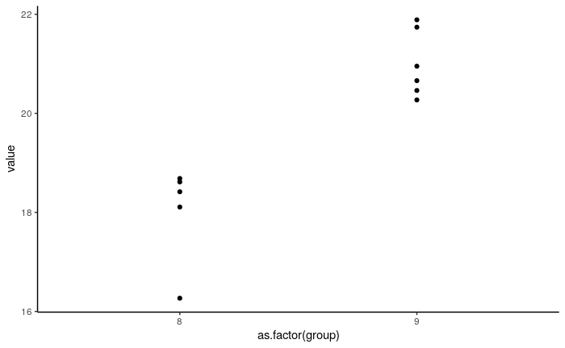

```r
best_hit_df <- cbind(value=unname(t(best_hit_vals)), design_df)
ggplot(best_hit_df, aes(x=as.factor(group), y=value)) + geom_point()
```

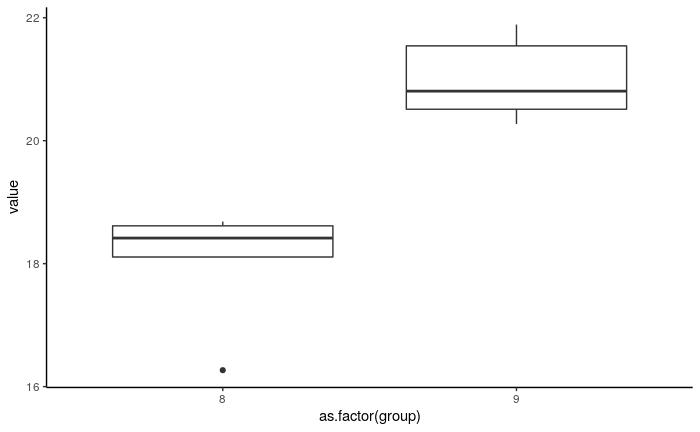

```r
ggplot(best_hit_df, aes(x=as.factor(group), y=value)) + geom_boxplot()
```

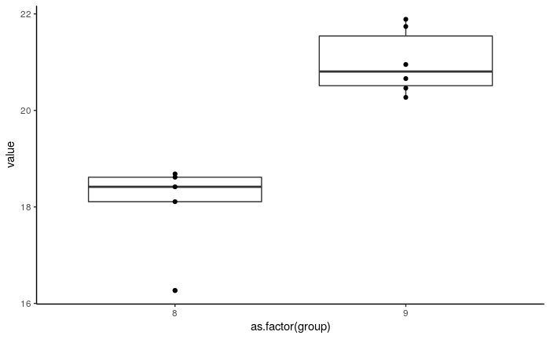

```r
ggplot(best_hit_df, aes(x=as.factor(group), y=value)) + geom_boxplot() + geom_point()
```

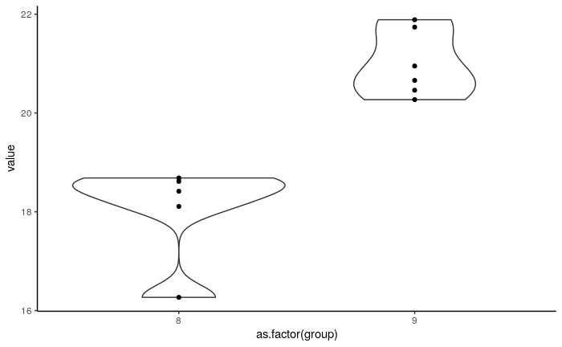

```r
ggplot(best_hit_df, aes(x=as.factor(group), y=value)) + geom_violin() + geom_point()
```

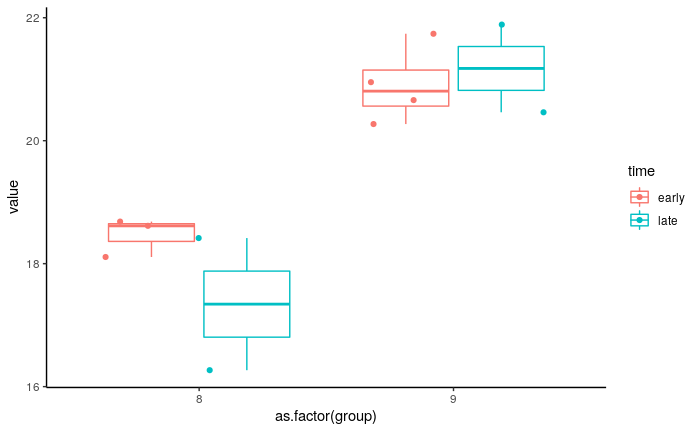

```r
ggplot(best_hit_df, aes(x=as.factor(group), y=value, color=time)) + geom_boxplot() + geom_point(position=position_jitterdodge())
```

# Preprocessing

Add column specifying whether or not they are significant.

```r
# Store the cutoff as a variable to make the code easier to read and reuse later
sig_thres <- 0.2
# full_data_df$Pvalue
# Base R
full_data_df$IsSig <- full_data_df$adj.P.Val < sig_thres
# Tidyverse
full_data_df <- full_data_df %>% mutate(IsSig = adj.P.Val < sig_thres)
# Inspect the results
head(full_data_df)
```

|  | Average.RT | Cluster.ID | Peptide.Sequence | External.IDs | Charge | Average.m.z | P.Value | adj.P.Val | log2Fold | AvgExpr | dil9_5 | dil9_4 | dil8_1 | dil8_2 | dil8_3 | dil9_3 | dil8_5 | dil8_4 | dil9_2 | dil9_1 | dil8_6 | dil9_6 | dil8_7 | dil9_7 | dil8_8 | dil9_8 | dil8_9 | dil9_9 | IsSig |
| --- | --- | --- | --- | --- | --- | --- | --- | --- | --- | --- | --- | --- | --- | --- | --- | --- | --- | --- | --- | --- | --- | --- | --- | --- | --- | --- | --- | --- | --- |
| 1 | 61.32530 | 1418128207109 | AAAAAAGDVFKDVQEAK | Q99Z57 | 3 | 554.6214 | 0.6773926 | 0.9998144 | 0.520363420 | 17.58087 | NA | 17.97114 | NA | NA | 18.73059 | NA | 16.63856 | 16.98317 | NA | NA | NA | NA | NA | NA | NA | NA | NA | NA | FALSE |
| 2 | 99.03974 | 1418128190676 | AAADYLEVPLYTYLGGFNTK | P69949 | 2 | 1103.5547 | 0.3770416 | 0.9998144 | -0.460577131 | 17.40734 | NA | NA | NA | NA | NA | NA | NA | NA | NA | NA | 18.09947 | 17.74470 | 17.73883 | 16.64132 | 17.10829 | 17.74684 | 17.60395 | 16.57536 | FALSE |
| 3 | 98.97744 | 1418128188736 | AAADYLEVPLYTYLGGFNTK | P69949 | 3 | 736.0416 | 0.6867821 | 0.9998144 | 0.282537091 | 14.30422 | NA | NA | NA | NA | NA | NA | NA | NA | NA | NA | NA | 14.84994 | 14.36933 | 13.65260 | 13.32145 | 14.83394 | 14.79809 | NA | FALSE |
| 4 | 42.66328 | 1418128214098 | AAAEALAQEQAAK | Q9A1Z8 | 2 | 636.3341 | 0.8840833 | 0.9998144 | -0.089692270 | 17.87283 | 18.70998 | 18.17519 | 17.94717 | 18.48465 | 18.77886 | 18.86186 | 16.04935 | 15.71238 | 15.00452 | 15.58053 | 19.03427 | 18.69501 | 18.67079 | 18.12471 | 18.18855 | 18.76573 | 18.39302 | 18.53430 | FALSE |
| 5 | 52.43872 | 1418128213643 | AAAEGNFAGIER | Q99YE5 | 2 | 603.2997 | 0.9833695 | 0.9998144 | -0.008937177 | 18.92062 | 19.12293 | 18.67264 | 18.99337 | 18.97384 | 19.36756 | 19.41670 | 17.25360 | 17.59831 | 17.55021 | 17.46875 | 20.06490 | 19.43200 | 19.56391 | 19.11942 | 19.16025 | 19.76935 | 19.35004 | 19.69335 | FALSE |
| 6 | 69.56549 | 1418128215927,1418128232269 | AAAELALISGQKPLITK | Q9A1W2 | 2 | 862.5214 | 0.8341496 | 0.9998144 | 0.122805456 | 21.16187 | 20.41252 | 19.89131 | 20.08161 | 19.82381 | 21.27203 | 21.00412 | 19.43886 | 19.46593 | 20.69190 | 19.90472 | 22.96216 | 21.87029 | 21.91014 | 21.93753 | 22.37153 | 23.05443 | 22.57813 | 22.24263 | FALSE |

# Inspect the p-values

Let’s inspect how many entries we have passing our assigned threshold.

Note the difference in base R the comma placement makes.

- my_df[1:10, ] - will slice out the first ten rows
- my_df[, 1:10] - will slice out the first ten columns

For base R we must also ensure there is no NA values

```r
# Base R
# Retrieve all rows where adj.P.Val < sig_thres and count them using nrow
nrow(full_data_df[full_data_df$adj.P.Val < sig_thres & !is.na(full_data_df$adj.P.Val), ])
```

```
[1] 17
```

```r
full_data_df[order(full_data_df$P.Value), ]
```

|  | Average.RT | Cluster.ID | Peptide.Sequence | External.IDs | Charge | Average.m.z | P.Value | adj.P.Val | log2Fold | AvgExpr | dil9_5 | dil9_4 | dil8_1 | dil8_2 | dil8_3 | dil9_3 | dil8_5 | dil8_4 | dil9_2 | dil9_1 | dil8_6 | dil9_6 | dil8_7 | dil9_7 | dil8_8 | dil9_8 | dil8_9 | dil9_9 | IsSig |
| --- | --- | --- | --- | --- | --- | --- | --- | --- | --- | --- | --- | --- | --- | --- | --- | --- | --- | --- | --- | --- | --- | --- | --- | --- | --- | --- | --- | --- | --- |
| 3495 | 60.26076 | 1418128185272,1418128223206 | VCFQYLNR | hum272 | 2 | 550.2725 | 0.0001043932 | 0.1214715 | 2.9771656 | 19.64220 | NA | NA | NA | NA | 18.41610 | 21.88865 | 16.267182 | NA | NA | 20.461979 | NA | 20.66011 | 18.61546 | 20.27065 | 18.10826 | 21.73932 | 18.68445 | 20.95204 | TRUE |
| 1469 | 60.60463 | 1418128210770 | IALDFQR | hum210 | 2 | 431.7433 | 0.0001483525 | 0.1214715 | 1.9618958 | 18.80728 | 20.188507 | 19.66857 | 17.99485 | 18.37609 | 18.50994 | 20.37002 | 16.229373 | 16.699505 | 18.29133 | 18.437996 | 18.65345 | 20.14669 | 18.16291 | 19.68011 | 17.84140 | 21.10707 | 17.96952 | 20.20381 | TRUE |
| 864 | 39.67873 | 1418128213014 | ENAGEDPGLAR | hum240 | 2 | 564.7685 | 0.0001660904 | 0.1214715 | 2.0262603 | 18.51726 | 18.940219 | 18.73956 | 17.02382 | 17.06114 | NA | NA | NA | NA | NA | NA | NA | 19.83402 | 17.97490 | 19.57531 | 17.16462 | 19.91811 | 17.83567 | 19.62251 | TRUE |
| 1053 | 48.64133 | 1418128214834 | FLGEVHCGTNVR | hum269 | 2 | 694.8409 | 0.0002228151 | 0.1214715 | 1.6322913 | 16.72149 | 17.476976 | 17.06073 | 15.00175 | 15.69515 | 16.46954 | 18.32329 | NA | NA | 16.50913 | NA | NA | 17.55349 | 16.10982 | 17.09761 | 15.68256 | 17.77533 | 15.77371 | 17.57183 | TRUE |
| 125 | 62.81780 | 1418128211443 | AGLQFPVGR | hum284 | 2 | 472.7698 | 0.0002243532 | 0.1214715 | 1.9516824 | 19.69827 | 20.888763 | 20.39044 | 18.65152 | 18.90877 | 19.39108 | 21.16600 | 17.279393 | 17.454540 | 19.17637 | 19.230630 | 19.69910 | 21.03337 | 19.15981 | 20.56503 | 18.79018 | 22.10187 | 19.16744 | 21.51451 | TRUE |
| 1432 | 49.44278 | 1418128215034 | HSDAVFTDNYTR | hum163 | 2 | 713.3251 | 0.0002383996 | 0.1214715 | 2.3958747 | 16.68474 | 17.362646 | 16.68158 | 15.11930 | 15.14777 | 16.25041 | 17.65572 | 14.302946 | 14.902234 | 16.31986 | 16.273623 | NA | 18.25063 | NA | 18.03754 | NA | 19.03499 | NA | 18.24705 | TRUE |
| 955 | 66.13783 | 1418128208707 | EVVSAQPATFLAR | hum307 | 2 | 694.8816 | 0.0002497847 | 0.1214715 | 2.4491429 | 20.34249 | 21.059169 | 20.47791 | 18.88722 | 18.94473 | NA | 21.25776 | 17.668435 | 17.487557 | NA | NA | 20.77845 | 21.94547 | 19.97920 | 21.55275 | 19.80172 | 22.85359 | 20.04910 | 22.39421 | TRUE |
| 1487 | 54.86546 | 1418128212410 | ICLDPDAPR | hum172 | 2 | 528.7612 | 0.0002946439 | 0.1214715 | 1.8929359 | 19.83471 | 20.484782 | 19.98674 | 18.66039 | 18.70365 | NA | NA | NA | NA | NA | NA | NA | 20.95635 | NA | 20.34148 | 18.48760 | 20.97726 | 18.94414 | 20.80469 | TRUE |
| 3968 | 65.73556 | 1418128211961 | YPLIQTLR | hum303 | 2 | 502.3007 | 0.0003057906 | 0.1214715 | 2.0234001 | 20.56865 | 21.843095 | 21.29442 | 19.68592 | 19.77962 | NA | 21.64375 | 18.168222 | 18.052011 | 20.07023 | 20.090384 | 20.64930 | 21.95548 | 19.97987 | 21.47881 | 19.66108 | 22.89576 | 20.00347 | 22.41561 | TRUE |
| 456 | 52.09040 | 1418128208683 | CLDPVDTPNPTR | hum176 | 2 | 692.8308 | 0.0003248835 | 0.1214715 | 1.7977480 | 18.02561 | 18.823538 | 18.48760 | 16.94636 | NA | 17.47531 | 19.32307 | 15.797097 | 16.223670 | 17.59691 | 17.577362 | NA | 19.56745 | 17.76484 | 19.02172 | 17.40982 | 19.49679 | 17.48357 | 19.41473 | TRUE |

[output cut: 990 more lines]

```r
# Tidyverse
full_data_df %>% filter(adj.P.Val < sig_thres) %>% nrow()
```

```
[1] 17
```

```r
full_data_df %>% arrange(P.Value)
```

| Average.RT | Cluster.ID | Peptide.Sequence | External.IDs | Charge | Average.m.z | P.Value | adj.P.Val | log2Fold | AvgExpr | dil9_5 | dil9_4 | dil8_1 | dil8_2 | dil8_3 | dil9_3 | dil8_5 | dil8_4 | dil9_2 | dil9_1 | dil8_6 | dil9_6 | dil8_7 | dil9_7 | dil8_8 | dil9_8 | dil8_9 | dil9_9 | IsSig |
| --- | --- | --- | --- | --- | --- | --- | --- | --- | --- | --- | --- | --- | --- | --- | --- | --- | --- | --- | --- | --- | --- | --- | --- | --- | --- | --- | --- | --- |
| 60.26076 | 1418128185272,1418128223206 | VCFQYLNR | hum272 | 2 | 550.2725 | 0.0001043932 | 0.1214715 | 2.9771656 | 19.64220 | NA | NA | NA | NA | 18.41610 | 21.88865 | 16.267182 | NA | NA | 20.461979 | NA | 20.66011 | 18.61546 | 20.27065 | 18.10826 | 21.73932 | 18.68445 | 20.95204 | TRUE |
| 60.60463 | 1418128210770 | IALDFQR | hum210 | 2 | 431.7433 | 0.0001483525 | 0.1214715 | 1.9618958 | 18.80728 | 20.188507 | 19.66857 | 17.99485 | 18.37609 | 18.50994 | 20.37002 | 16.229373 | 16.699505 | 18.29133 | 18.437996 | 18.65345 | 20.14669 | 18.16291 | 19.68011 | 17.84140 | 21.10707 | 17.96952 | 20.20381 | TRUE |
| 39.67873 | 1418128213014 | ENAGEDPGLAR | hum240 | 2 | 564.7685 | 0.0001660904 | 0.1214715 | 2.0262603 | 18.51726 | 18.940219 | 18.73956 | 17.02382 | 17.06114 | NA | NA | NA | NA | NA | NA | NA | 19.83402 | 17.97490 | 19.57531 | 17.16462 | 19.91811 | 17.83567 | 19.62251 | TRUE |
| 48.64133 | 1418128214834 | FLGEVHCGTNVR | hum269 | 2 | 694.8409 | 0.0002228151 | 0.1214715 | 1.6322913 | 16.72149 | 17.476976 | 17.06073 | 15.00175 | 15.69515 | 16.46954 | 18.32329 | NA | NA | 16.50913 | NA | NA | 17.55349 | 16.10982 | 17.09761 | 15.68256 | 17.77533 | 15.77371 | 17.57183 | TRUE |
| 62.81780 | 1418128211443 | AGLQFPVGR | hum284 | 2 | 472.7698 | 0.0002243532 | 0.1214715 | 1.9516824 | 19.69827 | 20.888763 | 20.39044 | 18.65152 | 18.90877 | 19.39108 | 21.16600 | 17.279393 | 17.454540 | 19.17637 | 19.230630 | 19.69910 | 21.03337 | 19.15981 | 20.56503 | 18.79018 | 22.10187 | 19.16744 | 21.51451 | TRUE |
| 49.44278 | 1418128215034 | HSDAVFTDNYTR | hum163 | 2 | 713.3251 | 0.0002383996 | 0.1214715 | 2.3958747 | 16.68474 | 17.362646 | 16.68158 | 15.11930 | 15.14777 | 16.25041 | 17.65572 | 14.302946 | 14.902234 | 16.31986 | 16.273623 | NA | 18.25063 | NA | 18.03754 | NA | 19.03499 | NA | 18.24705 | TRUE |
| 66.13783 | 1418128208707 | EVVSAQPATFLAR | hum307 | 2 | 694.8816 | 0.0002497847 | 0.1214715 | 2.4491429 | 20.34249 | 21.059169 | 20.47791 | 18.88722 | 18.94473 | NA | 21.25776 | 17.668435 | 17.487557 | NA | NA | 20.77845 | 21.94547 | 19.97920 | 21.55275 | 19.80172 | 22.85359 | 20.04910 | 22.39421 | TRUE |
| 54.86546 | 1418128212410 | ICLDPDAPR | hum172 | 2 | 528.7612 | 0.0002946439 | 0.1214715 | 1.8929359 | 19.83471 | 20.484782 | 19.98674 | 18.66039 | 18.70365 | NA | NA | NA | NA | NA | NA | NA | 20.95635 | NA | 20.34148 | 18.48760 | 20.97726 | 18.94414 | 20.80469 | TRUE |
| 65.73556 | 1418128211961 | YPLIQTLR | hum303 | 2 | 502.3007 | 0.0003057906 | 0.1214715 | 2.0234001 | 20.56865 | 21.843095 | 21.29442 | 19.68592 | 19.77962 | NA | 21.64375 | 18.168222 | 18.052011 | 20.07023 | 20.090384 | 20.64930 | 21.95548 | 19.97987 | 21.47881 | 19.66108 | 22.89576 | 20.00347 | 22.41561 | TRUE |
| 52.09040 | 1418128208683 | CLDPVDTPNPTR | hum176 | 2 | 692.8308 | 0.0003248835 | 0.1214715 | 1.7977480 | 18.02561 | 18.823538 | 18.48760 | 16.94636 | NA | 17.47531 | 19.32307 | 15.797097 | 16.223670 | 17.59691 | 17.577362 | NA | 19.56745 | 17.76484 | 19.02172 | 17.40982 | 19.49679 | 17.48357 | 19.41473 | TRUE |

[output cut: 990 more lines]

# Visualize

## P-value histogram

For further discussion on its interpretation, see the following link: http://varianceexplained.org/statistics/interpreting-pvalue-histogram/

Special settings:

- geom_histogram - Geometry specifying to do histograms, where we are cutting up a range of data in bins
- bins - Specify how many segments the data should be separated in

When running this you get a warning “Removed 43 rows containing non-finite values (stat_bin)”. This is due to missing values in the dataset.

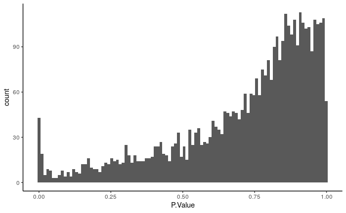

```r
ggplot(full_data_df, aes(x=P.Value)) + geom_histogram(bins=100)
```

This can easily be adjusted to other characteristics, such as expression or fold change:

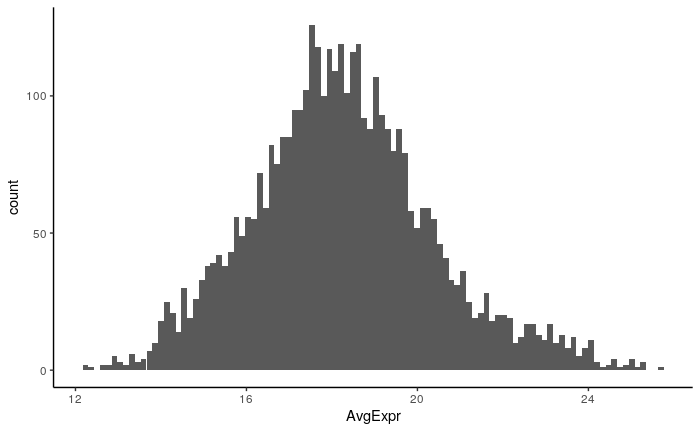

```r
ggplot(full_data_df, aes(x=AvgExpr)) + geom_histogram(bins=100)
```

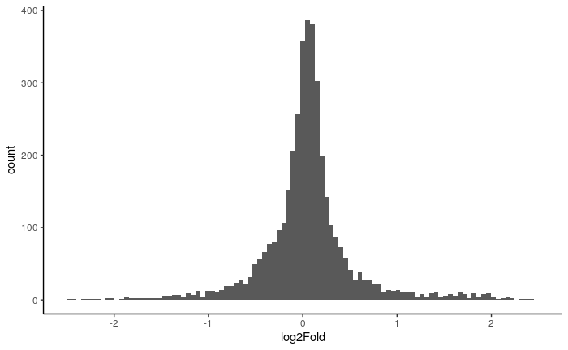

```r
ggplot(full_data_df, aes(x=log2Fold)) + geom_histogram(bins=100) + xlim(-2.5, 2.5)
```

If you want to color those entries that pass your adjusted p-value threshold, you can use the `fill` option. There are two coloring options - `fill` and `color`. Which one is applicable depends on the data type.

We see that around half the p-values < 0.01 are found below FDR < 0.2

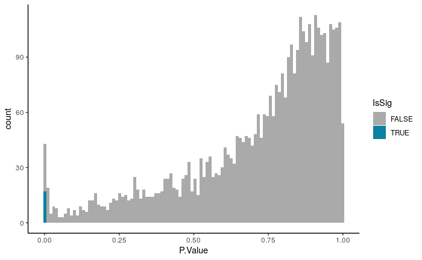

```r
gray_blue_colors <- c("#AAAAAA", "#0C81A2")
phist_plt <- ggplot(full_data_df, aes(x=P.Value, fill=IsSig)) + geom_histogram(bins=100) + scale_fill_manual(values=gray_blue_colors)
phist_plt
```

## Vulcano plot

The Vulcano plot illustrates the regulation patterns within your dataset compared to their significance - How clearly they are found to be regulated.

Thinking point: When can we have a large fold change but still have a large p-value?

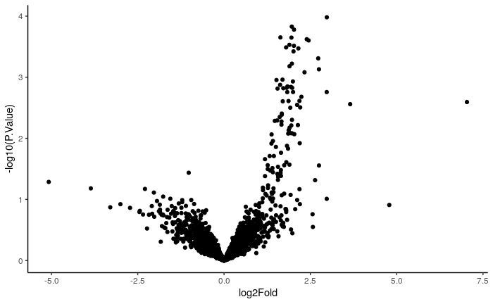

```r
ggplot(full_data_df, aes(x=log2Fold, y=-log10(P.Value))) + geom_point()
```

You can color the significant hits here too

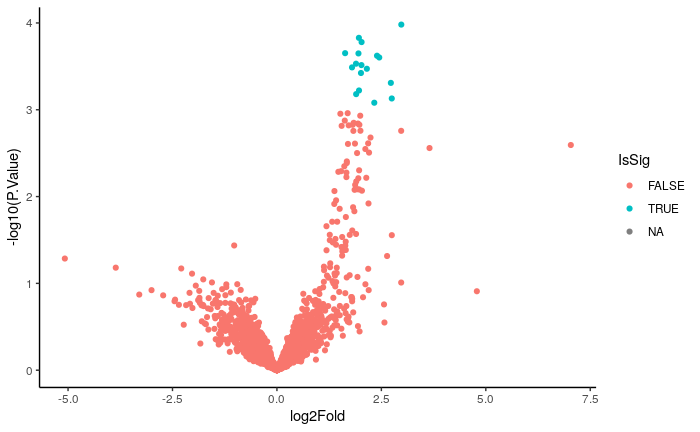

```r
ggplot(full_data_df, aes(x=log2Fold, y=-log10(P.Value), color=IsSig)) + geom_point()
```

You can adjust settings to make it look more ‘publication quality’

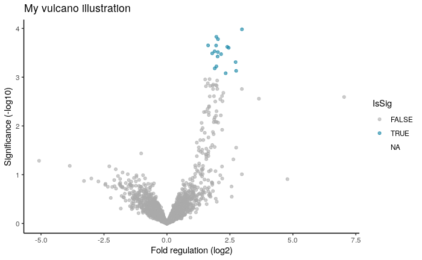

```r
vulc_plt <- ggplot(full_data_df, aes(x=log2Fold, y=-log10(P.Value), color=IsSig)) +
    geom_point(alpha=0.6, na.rm=TRUE) +
    ggtitle("My vulcano illustration") +
    xlab("Fold regulation (log2)") +
    ylab("Significance (-log10)") +
    scale_color_manual(values=gray_blue_colors)
vulc_plt
```

## MA plot

Very similar to the vulcano plot, with the only difference what we are specifying as x-axis and y-axis.

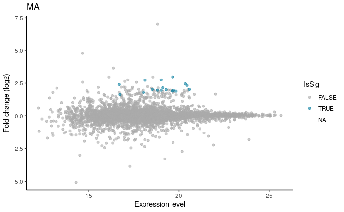

```r
ma_plt <- ggplot(full_data_df %>% arrange(desc(P.Value)), aes(x=AvgExpr, y=log2Fold, color=IsSig)) +
    geom_point(alpha=0.6, na.rm=TRUE) +
    ggtitle("MA") +
    xlab("Expression level") +
    ylab("Fold change (log2)") +
    scale_color_manual(values=gray_blue_colors)
ma_plt
```

# Preparing data in long format

## Wide vs. long formats

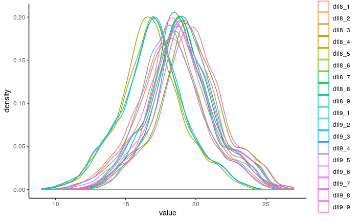

```r
long_data <- full_data_df %>% pivot_longer(as.character(design_df$sample), names_to="sample", values_to="value")
ggplot(long_data, aes(x=value, color=sample)) + geom_density()
```

Often we want to color on different conditions to look for patterns in the data. Then we need to merge in out design matrix into this long data.

This can be achieved using a `left_join` from the `dplyr` package.

```r
annot_long_data <- long_data %>% left_join(design_df, by="sample")
```

Now we can investigate patterns using the characteristics from the design matrix.

Note that we need to add the argument `group` for ggplot to realize that each line comes from its own sample. Feel free to try what you get without the argument.

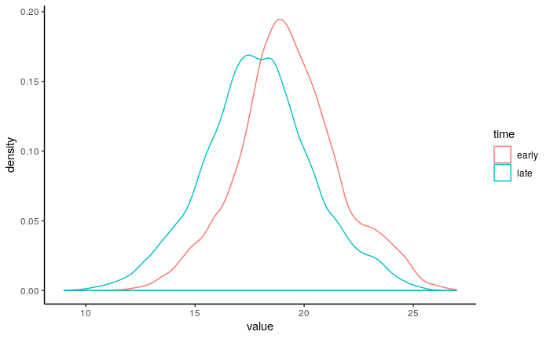

```r
ggplot(annot_long_data, aes(x=value, color=time)) + geom_density()
```

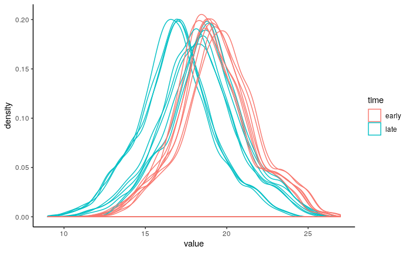

```r
ggplot(annot_long_data, aes(x=value, color=time, group=sample)) + geom_density()
```

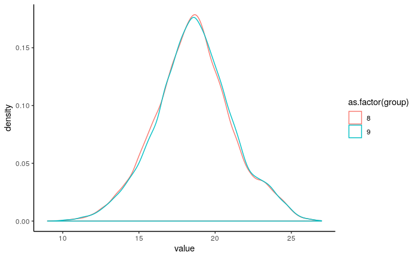

```r
ggplot(annot_long_data, aes(x=value, color=as.factor(group))) + geom_density()
```

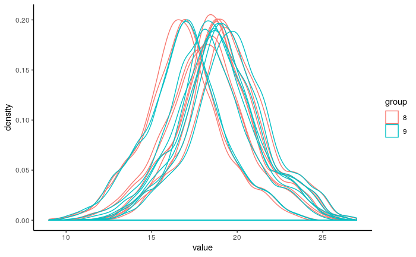

```r
ggplot(annot_long_data, aes(x=value, color=group, group=sample)) + geom_density()
```

## Boxplot or violins

Using this we can easily make other plots such as boxplots or violins

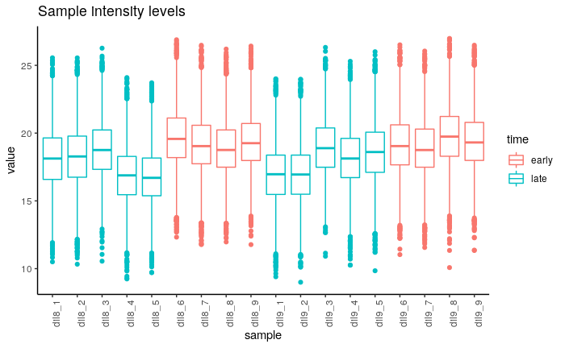

```r
box_plt <- ggplot(annot_long_data, aes(x=sample, y=value, color=time)) +
    geom_boxplot() +
    theme(axis.text.x = element_text(angle=90, hjust=1)) +
    ggtitle("Sample intensity levels")
box_plt
```

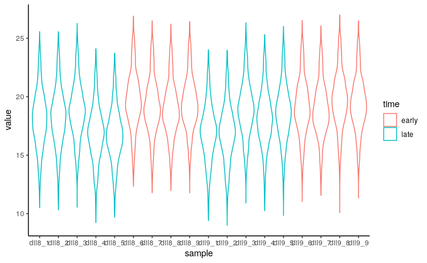

```r
ggplot(annot_long_data, aes(x=sample, y=value, color=time)) + geom_violin()
```

## Barplot

Illustration of total intensities in samples.

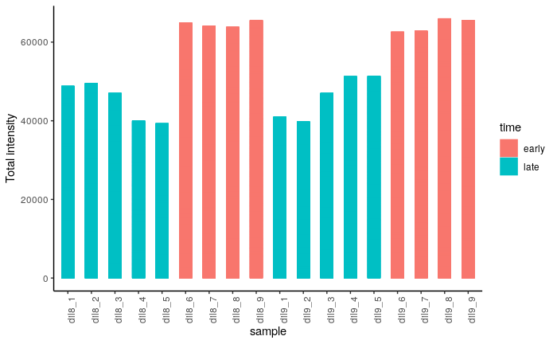

```r
ggplot(annot_long_data, aes(x=sample, y=value, fill=time, color=time, width=0.5)) + geom_col() + ylab("Total intensity") + theme(axis.text.x=element_text(angle=90))
```

# Special topics

## Making a multi-pane plot

You often want to combine multiple plots

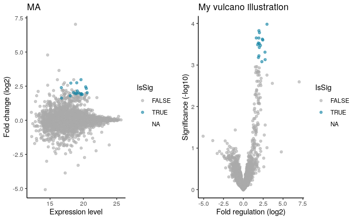

```r
library(ggpubr)
ggarrange(ma_plt, vulc_plt)
```

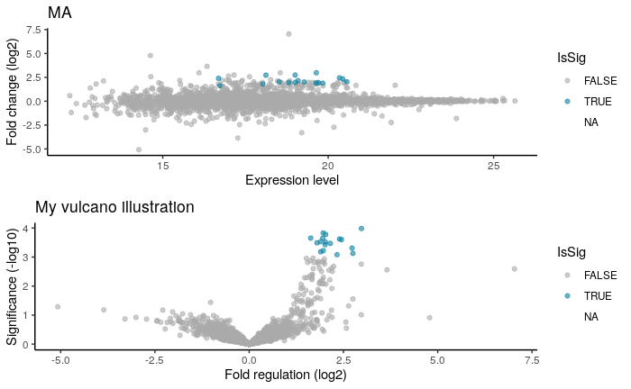

```r
ggarrange(ma_plt, vulc_plt, ncol=1)
```

```r
grid_plt <- ggarrange(ma_plt, vulc_plt, phist_plt, box_plt, common.legend = TRUE, legend = "right")
```

```
Removed 43 rows containing non-finite values (stat_bin).Removed 20006 rows containing non-finite values (stat_boxplot).
```

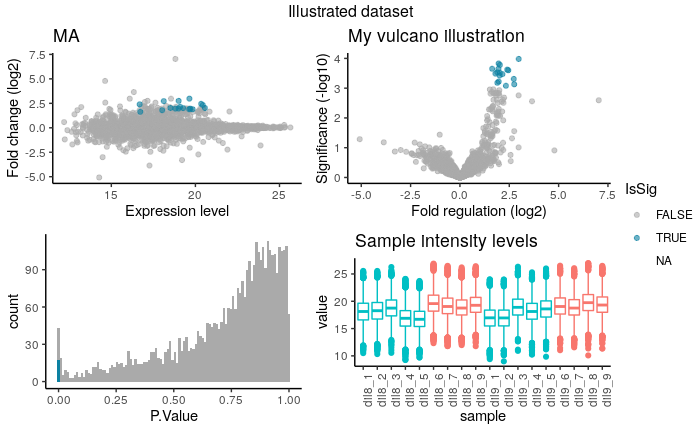

```r
annotated_plt <- annotate_figure(grid_plt, top="Illustrated dataset")
annotated_plt
```

## Saving plots to file

```r
ggsave(annotated_plt, filename = "output_path.png")
```

You can specify the measures,

```r
ggsave(annotated_plt, filename = "output_path_highres.png", width=10, height=10, dpi = 300)
```

# Special cases

## Heatmaps

Source: https://learnr.wordpress.com/2010/01/26/ggplot2-quick-heatmap-plotting/ Source for base R: https://www.r-graph-gallery.com/heatmap

Heatmaps can be done in ggplot using `geom_tile()`, but in this particular case I would recommend using the base R version due to its clustering of the entries.

[figure not shown]

## Principal component analysis

There are many ways to do principal component analysis visualizations in R. The one I find easiest to use is the `PCAtools` package.

Here is a nice vignette for more extensive examples: https://bioconductor.org/packages/release/bioc/vignettes/PCAtools/inst/doc/PCAtools.html

```r
library(PCAtools)
# Biplots for different components and colorings
# Pairplot
data_df_no_missing <- data_df[complete.cases(data_df), ]
p <- pca(data_df_no_missing, removeVar=0.1, scale=TRUE, metadata=as.matrix(design_df))
```

[output not shown]